# DWDM Kaggle Project

**Team members**

- Ambika Kaul
- Harshendra Avabratha

## Approach

- We started by learning about pandas, seaborn, other basic things about scikit-learn. (refer practice/notebooks of the github link).
- With no data preprocessing we used linear regression. Then did some data exploration about how to handle categorical data , missing values and skewness. For skewness, we learnt about Pearson coefficient and how it ranks the different features based on their correlations with the response.
- Then, we explored simple Random Forest and tried its combination with linear regression.
- Next, we tried understanding SVR, along with its parameter tuning using GridSearchCV.
- Looking around other kernels, we realized, XGBoost is also a powerful library and we wrote a simple code for it without tuning parameters.
- Then, tried XGBoost with GridSearchCV,
- Finally, tried a combination of the above regressors and based on a trial and error method (for ranks), came up with the uploaded code.
- Refer Github link for details of the above mentioned points.

https://github.com/dimtim1/DWDM-Kaggle-Project

[figure not shown]

```python
from IPython.display import Image
Image(filename='/home/harsha/Desktop/102.png')
```

## Below are some of the data exploration techniques we tried

```python
%matplotlib inline
import pandas as pd
import sklearn as sc
import numpy as np
import matplotlib as mp
from scipy.stats import skew
import csv
import matplotlib.pyplot as plt
import math
from sklearn.ensemble import RandomForestRegressor
from sklearn import linear_model
import xgboost as xgb
import matplotlib


from sklearn.linear_model import Ridge,RidgeCV,ElasticNet,LassoCV,LassoLarsCV
from sklearn.cross_validation import cross_val_score
from sklearn.ensemble import RandomForestRegressor



def preprocess(train,test):

    all_data = pd.concat((train.loc[:,'MSSubClass':'SaleCondition'],
                          test.loc[:,'MSSubClass':'SaleCondition']))

    #dropping columns
    all_data.drop('MiscVal',axis=1)
    all_data.drop('MiscFeature',axis=1)
    all_data.drop('3SsnPorch',axis=1)
    all_data.drop('ScreenPorch',axis=1)
    all_data.drop('EnclosedPorch',axis=1)
    all_data.drop('KitchenAbvGr',axis=1)
    all_data.drop('BsmtHalfBath',axis=1)

    matplotlib.rcParams['figure.figsize'] = (12.0, 6.0)
    prices = pd.DataFrame({"price":train["SalePrice"], "log(price + 1)":np.log1p(train["SalePrice"])})
    prices.hist()

    #log transform the target:
    train["SalePrice"] = np.log1p(train["SalePrice"])

    #log transform skewed numeric features:
    numeric_feats = all_data.dtypes[all_data.dtypes != "object"].index
    #categorical_feats= all_data.dtypes[all_data.dtypes == "object"].index

    # print numeric_feats
    skewed_feats = train[numeric_feats].apply(lambda x: skew(x.dropna())) #compute skewness
    skewed_feats = skewed_feats[skewed_feats > 0.5]
    skewed_feats = skewed_feats.index
    # numeric_feats=numeric_feats.index

    #print skewed_feats

    all_data[skewed_feats] = np.log1p(all_data[skewed_feats])

    #print 1,all_data.shape
    all_data = pd.get_dummies(all_data)

    #filling NA's with the mean of the column:
    all_data = all_data.fillna(all_data[:train.shape[0]].mean())

    #creating matrices for sklearn:
    X_train = all_data[:train.shape[0]]
    X_test = all_data[train.shape[0]:]

    y = train.SalePrice

    return X_train,X_test,y


def getModels(train,y):

    model_rf = RandomForestRegressor(n_estimators=100)
    model_rf.fit(X_train,y)

    model_lasso = LassoCV(alphas = [1, 0.1, 0.001, 0.0005]).fit(X_train, y)

    dtrain = xgb.DMatrix(X_train, label = y)
    dtest = xgb.DMatrix(X_test)

    model_xgb = xgb.XGBRegressor(n_estimators=360, max_depth=2, learning_rate=0.07) #the params were tuned using xgb.cv
    model_xgb.fit(X_train, y)

    return (model_rf,model_lasso,model_xgb)


def predict(X_test,model):
    return np.expm1(model.predict(X_test))
```

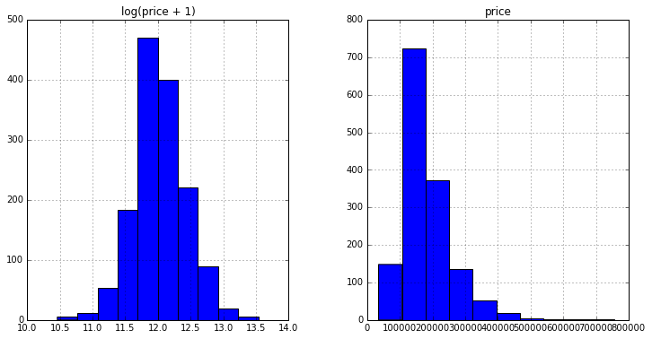

```python
test=pd.read_csv('../../data/test.csv')
train=pd.read_csv('../../data/train.csv')

X_train,X_test,y = preprocess(train,test)
```

- As we can see the Sale price is skewed. Hence we do a logarithmic tranformation of sale price along with other attributes.
- The skewness is measured using the scipy.stats library function [skew](http://docs.scipy.org/doc/scipy/reference/generated/scipy.stats.skew.html).

# XGBoost

```python
dtrain = xgb.DMatrix(X_train, label = y)
dtest = xgb.DMatrix(X_test)

params = {"max_depth":2, "eta":0.1}
model = xgb.cv(params, dtrain,  num_boost_round=500, early_stopping_rounds=100)
```

```
Will train until cv error hasn't decreased in 100 rounds.
```

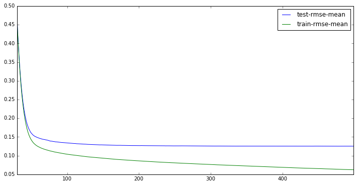

```python
model.loc[30:,["test-rmse-mean", "train-rmse-mean"]].plot()
```

- We chose n_estimators somewhere around 350

# Lasso

## Feature selection using lasso model

```python
model_lasso = LassoCV(alphas = [1, 0.1, 0.001, 0.0005]).fit(X_train, y)
coef = pd.Series(model_lasso.coef_, index = X_train.columns)
```

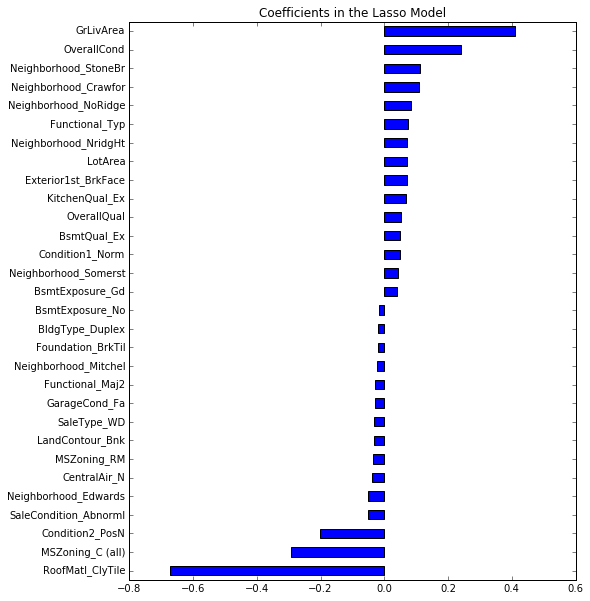

```python
imp_coef = pd.concat([coef.sort_values().head(15),
                     coef.sort_values().tail(15)])


matplotlib.rcParams['figure.figsize'] = (8.0, 10.0)
imp_coef.plot(kind = "barh")
plt.title("Coefficients in the Lasso Model")
```

# Random Forest

```python
model_rf = RandomForestRegressor(n_estimators=100)
model_rf.fit(X_train,y)
```

```
RandomForestRegressor(bootstrap=True, criterion='mse', max_depth=None,
           max_features='auto', max_leaf_nodes=None, min_samples_leaf=1,
           min_samples_split=2, min_weight_fraction_leaf=0.0,
           n_estimators=100, n_jobs=1, oob_score=False, random_state=None,
           verbose=0, warm_start=False)
```

## Feature importance using Random Forest

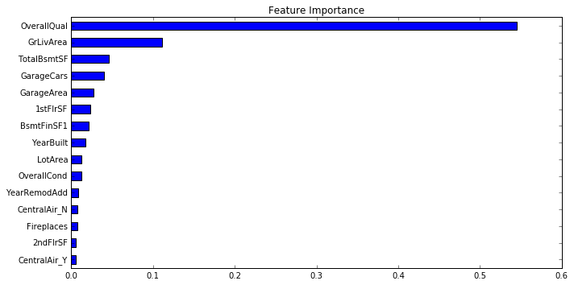

```python
coef = pd.Series(model_rf.feature_importances_,index=X_train.columns)
imp_coef = pd.concat([coef.sort_values().tail(15)])
plt.figure(figsize=(10,5))
imp_coef.head(20).plot(kind='barh')
plt.title('Feature Importance')
plt.tight_layout()
```

## So we combine Lasso, XGBoost and Random Forest models to create a hybrid model.

[figure not shown]

```python
model_rf,model_lasso,model_xgb = getModels(X_train,y)

rf_preds = predict(X_train,model_rf)
lasso_preds = predict(X_train,model_lasso)
xgb_preds = predict(X_train,model_xgb)

preds= 0.7*lasso_preds+0.2*xgb_preds+0.1*rf_preds
y= np.expm1(y)
plt.figure(figsize=(10, 5))
plt.scatter(y, preds, s=20)
plt.title('Predicted vs. Actual')
plt.xlabel('Actual Sale Price')
plt.ylabel('Predicted Sale Price')


#plt.plot([min(y), max(y)], [min(preds), max(preds)])
plt.tight_layout()
```